# Trabalho1

Pedro Portela

10 de abril de 2018

# Trabalho 1 - Tópicos Especiais em Pesquisa Operacional

A base dados escolhida para o trabalho foi de voos registrados pela Agência Nacional de Aviação Civil (ANAC) no Brasil, entre Janeiro de 2015 e Agosto de 2017. O foco será no aeroporto Hercílio Luz, de Florianópolis.

Dados disponíveis em: https://www.kaggle.com/ramirobentes/flights-in-brazil

### Visualização inicial

```r
# Voos com origem em Florianopolis
top_n(flnFlightsOut, n=5)
```

```
## # A tibble: 5 x 22
##   Voos       Companhia.Aerea Codigo.Tipo.Linha Partida.Prevista
##   <chr>      <chr>           <chr>             <dttm>
## 1 AZU - 2787 AZUL            Nacional          2016-03-14 06:30:00
## 2 AZU - 4064 AZUL            Nacional          2016-03-14 11:18:00
## 3 AZU - 6967 AZUL            Nacional          2016-03-14 17:50:00
## 4 GLO - 1509 GOL             Nacional          2016-03-14 16:24:00
## 5 ONE - 6318 AVIANCA BRASIL  Nacional          2016-03-14 23:15:00
## # ... with 18 more variables: Partida.Real <dttm>,
## #   Chegada.Prevista <dttm>, Chegada.Real <dttm>, Situacao.Voo <chr>,
## #   Codigo.Justificativa <chr>, Aeroporto.Origem <chr>,
## #   Cidade.Origem <chr>, Estado.Origem <chr>, Pais.Origem <chr>,
## #   Aeroporto.Destino <chr>, Cidade.Destino <chr>, Estado.Destino <chr>,
## #   Pais.Destino <chr>, LongDest <dbl>, LatDest <dbl>, LongOrig <dbl>,
## #   LatOrig <dbl>, Atrasos <int>
```

```r
# Voos com destino em Florianopolis
top_n(flnFlightsIn, n=5)
```

```
## # A tibble: 5 x 22
##   Voos       Companhia.Aerea Codigo.Tipo.Linha Partida.Prevista
##   <chr>      <chr>           <chr>             <dttm>
## 1 AZU - 2786 AZUL            Nacional          2016-03-14 22:45:00
## 2 AZU - 2906 AZUL            Nacional          2016-03-14 18:04:00
## 3 GLO - 1504 GOL             Nacional          2016-03-14 11:10:00
## 4 GLO - 2080 GOL             Nacional          2016-03-14 19:55:00
## 5 ONE - 6318 AVIANCA BRASIL  Nacional          2016-03-14 21:45:00
## # ... with 18 more variables: Partida.Real <dttm>,
## #   Chegada.Prevista <dttm>, Chegada.Real <dttm>, Situacao.Voo <chr>,
## #   Codigo.Justificativa <chr>, Aeroporto.Origem <chr>,
## #   Cidade.Origem <chr>, Estado.Origem <chr>, Pais.Origem <chr>,
## #   Aeroporto.Destino <chr>, Cidade.Destino <chr>, Estado.Destino <chr>,
## #   Pais.Destino <chr>, LongDest <dbl>, LatDest <dbl>, LongOrig <dbl>,
## #   LatOrig <dbl>, Atrasos <int>
```

### Exploração de dados

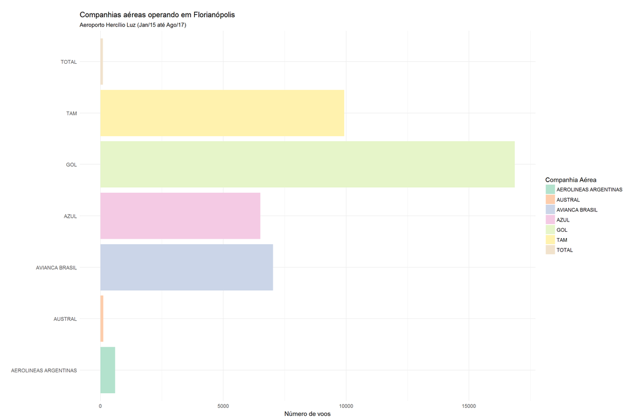

Destaque para a Gol, com um volume de voos consideravelmente maior que as outras companhias (no período).

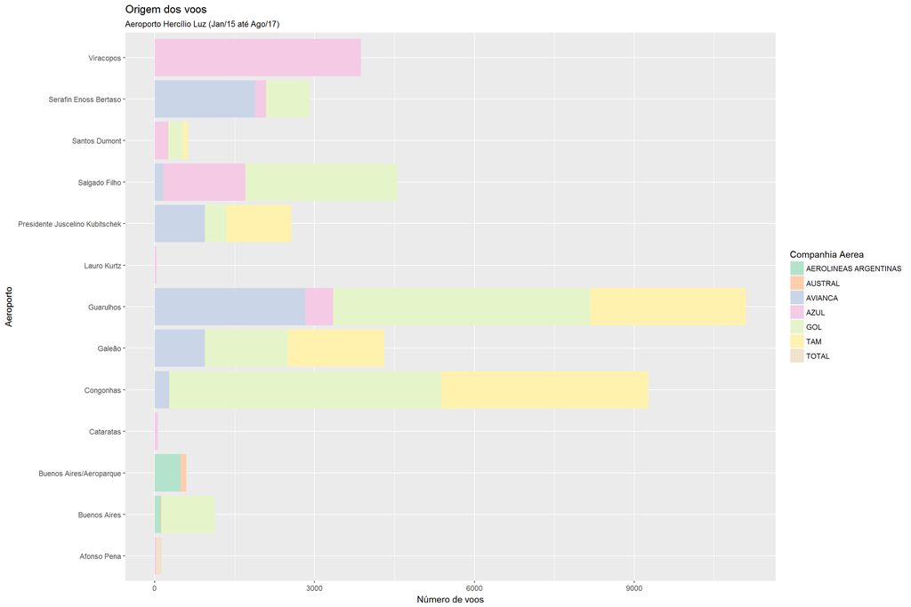

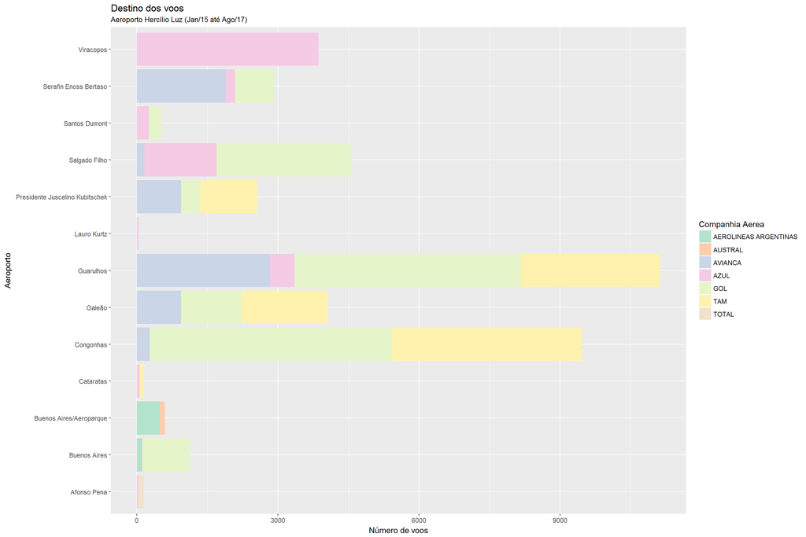

Poucas diferenças entre as origens e destinos. Notavelmente, rota da TAM com origem no Aeroporto Santos Dummont (RJ) não tem voo de retorno.

## Análise de atrasos

Considerando atrasos de até 4 horas. Atrasos maiores são [categorizados diferentemente pela ANAC](http://www.anac.gov.br/assuntos/passageiros/atrasos-cancelamentos-pretericao-e-assistencia-material), surgindo a obrigação por parte da companhia aérea de fornecer reacomodação, reembolso integral e execução do serviço por outra modalidade de transporte, cabendo a escolha ao passageiro pelo cancelamento ou preterição de embarque.

### Visualização inicial - Atrasos

```r
#Maiores atrasos nos voos saíndo de Florianópolis
arrangedDelays <- select(arrange(flnFlightsOut, desc(Atrasos)), Atrasos, Companhia.Aerea, Codigo.Justificativa, Partida.Prevista, everything())
head(arrangedDelays)
```

```
## # A tibble: 6 x 22
##   Atrasos Companhia.Aerea Codigo.Justificativa  Partida.Prevista    Voos
##     <int> <chr>           <chr>                 <dttm>              <chr>
## 1   14454 AVIANCA BRASIL  DEFEITOS DA AERONAVE  2016-03-14 23:15:00 ONE -~
## 2   14398 AZUL            ANTECIPACAO DE HORAR~ 2016-03-14 11:18:00 AZU -~
## 3   14395 AZUL            ANTECIPACAO DE HORAR~ 2016-03-14 17:50:00 AZU -~
## 4   14394 AZUL            ANTECIPACAO DE HORAR~ 2016-03-14 06:30:00 AZU -~
## 5   14362 GOL             ANTECIPACAO DE HORAR~ 2016-03-14 16:24:00 GLO -~
## 6    7234 GOL             CONEXAO DE AERONAVE   2016-03-15 21:20:00 GLO -~
## # ... with 17 more variables: Codigo.Tipo.Linha <chr>,
## #   Partida.Real <dttm>, Chegada.Prevista <dttm>, Chegada.Real <dttm>,
## #   Situacao.Voo <chr>, Aeroporto.Origem <chr>, Cidade.Origem <chr>,
## #   Estado.Origem <chr>, Pais.Origem <chr>, Aeroporto.Destino <chr>,
## #   Cidade.Destino <chr>, Estado.Destino <chr>, Pais.Destino <chr>,
## #   LongDest <dbl>, LatDest <dbl>, LongOrig <dbl>, LatOrig <dbl>
```

```r
#Separando voos com atraso
delayedFlights <- filter(flnFlightsOut, Atrasos > 0 & Atrasos < 240)
```

Pela tabela ordenada por maiores atrasos, surge uma dúvida quanto à coleta dos dados: em alguns casos, a justificativa para o atraso é registrada como “Antecipação de horário autorizada”, mesmo que o voo tenha partido com um atraso bastante alto - em alguns casos, como mostrado, dias de atraso. Reforça-se, portanto, a análise de apenas atrasos “normais” (no máximo 4 horas), já que minimiza a utilização de dados conflitantes.

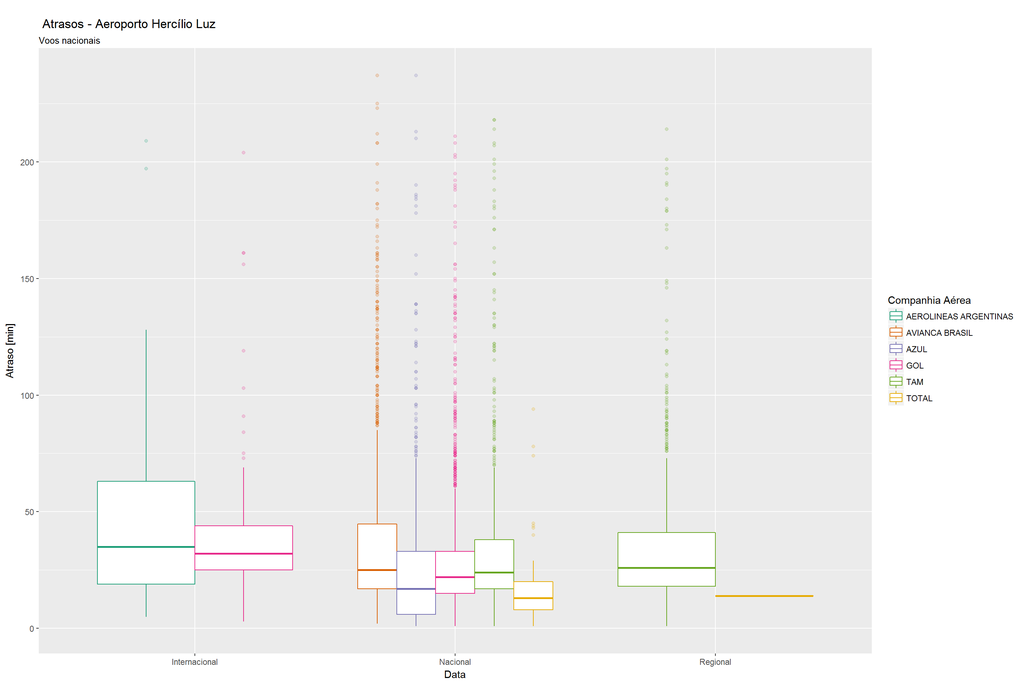

Interessante notar que voos nacionais com mais de ~75 minutos de atraso são considerados *outliers* neste agrupamento de dados. Destaque para a empresa TOTAL, com quartis próximos e menor número de atrasos acima de uma hora.

### Exploração adicional de atrasos - Gráficos de densidade

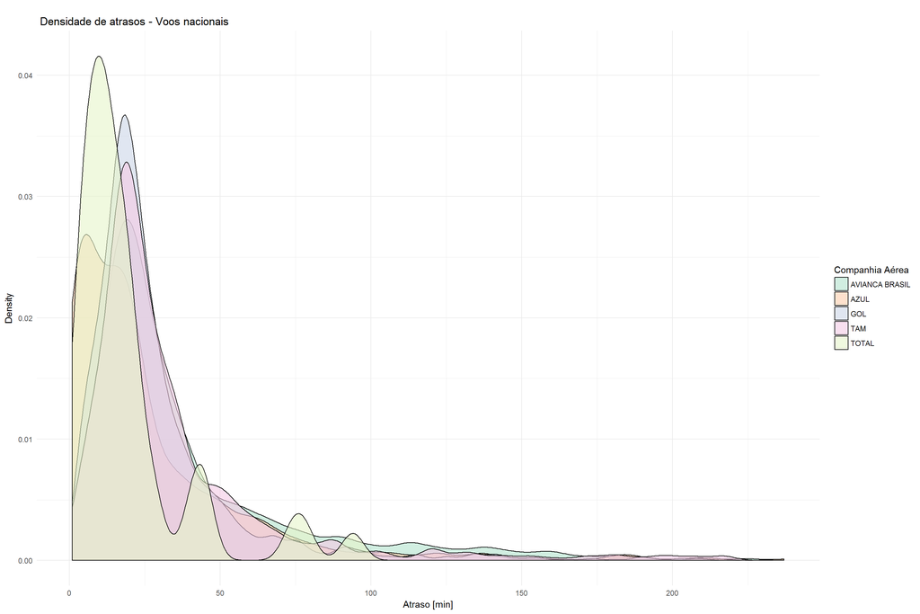

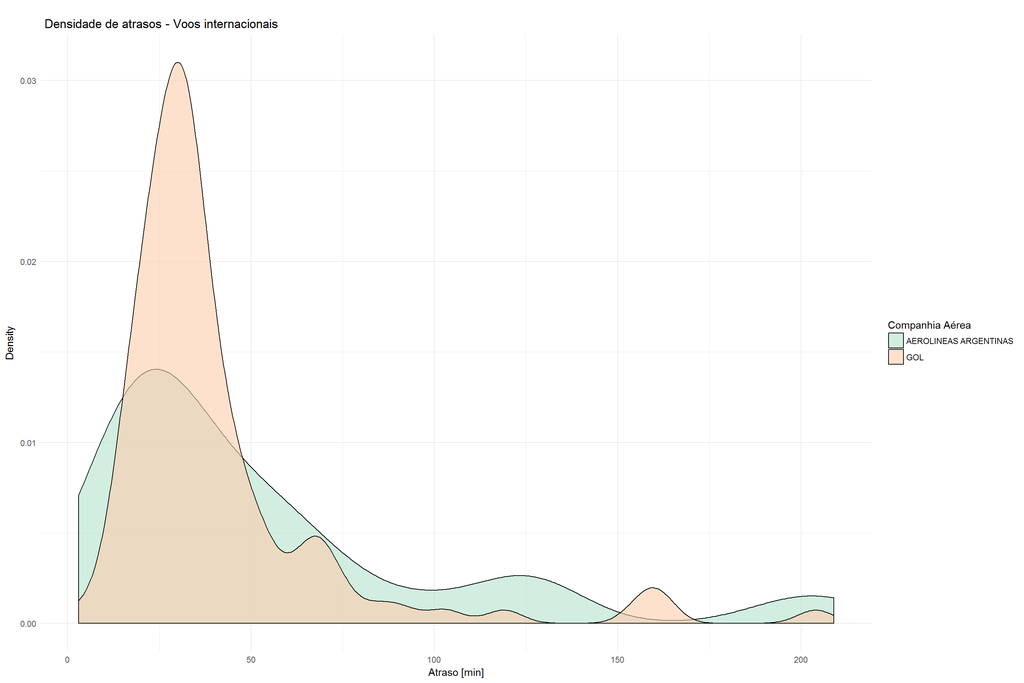

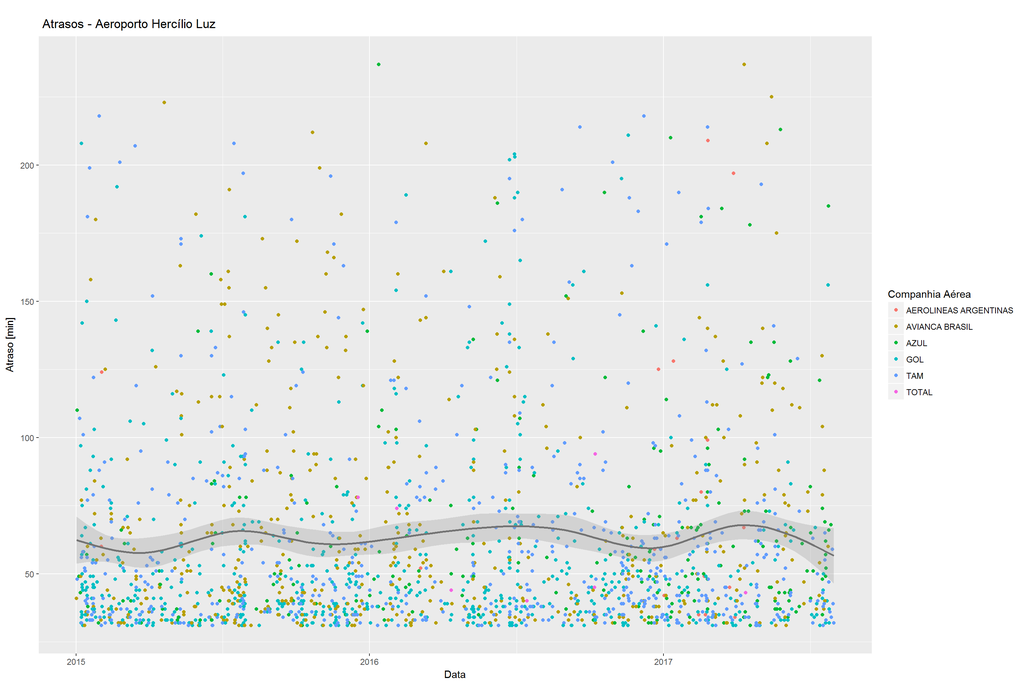

```r
#Contabilizados apenas atrasos entre 30 minutos e 4 horas (ANAC)
ggplot(data = filter(delayedFlights, Atrasos > 30)) +
  geom_point(aes(x=Partida.Prevista, y=Atrasos, color=Companhia.Aerea)) +
  geom_smooth(aes(x=Partida.Prevista, y=Atrasos), color='gray45', alpha=0.3) +
  labs(title = "\n Atrasos - Aeroporto Hercílio Luz", y = "Atraso [min]", x = "Data", color = "Companhia Aérea") +
  scale_fill_brewer(palette = 'Spectral')
```

Foram contabilizados atrasos de mais de 30 minutos pois, de acordo com as regras da ANAC, é a partir desse tempo que a empresa deve informar os passageiros sobre a situação do voo. Percebe-se uma certa sazonalidade nos atrasos, mas sem nenhuma tendência muito clara.

## Mapeamento de voos

Voos com conexões em outras cidades de Santa Catarina são considerados Regionais, mesmo que o destino final seja em outro Estado.

[figure not shown]

O código desenvolvido neste trabalho pode ser facilmente adaptado para a análise de outros aeroportos brasileiros. Para isso, seria necessário a recuperação dos dados originais disponíveis em: https://www.kaggle.com/ramirobentes/flights-in-brazil